# Copy_of_Welcome_to_Colaboratory

## **Introduction**

This Python script is designed to perform a comprehensive analysis of the Bank Nifty (NSE Index) stock data. The Bank Nifty index is a benchmark index for the Indian banking sector and is composed of the most liquid and large capitalized banking stocks listed on the National Stock Exchange of India (NSE). The script includes various analyses and predictions:

Time Series Forecasting of the closing prices of the Bank Nifty Index using a Long Short-Term Memory (LSTM) model. LSTMs are a type of recurrent neural network that are capable of learning patterns in sequences of data, such as time series data. Statistical Analysis of daily, weekly, and monthly returns, including their distributions. Trading Strategy Development, based on Chandelier Exit (a type of trailing stop loss order) and Average True Range (ATR), which are popular volatility-based indicators used by traders to set stop-loss orders.

```python
import numpy as np
import matplotlib.pyplot as plt
import math
import pandas as pd
import pandas_datareader as web
import yfinance as yf
from sklearn.preprocessing import MinMaxScaler
from keras.models import Sequential
from keras.layers import LSTM, Dense
from tensorflow.keras.optimizers import RMSprop
from tensorflow.keras.layers import Dropout
from tensorflow.keras.callbacks import EarlyStopping
plt.style.use('fivethirtyeight')
```

## **Data Collection**

The script begins by importing necessary Python packages and libraries and then fetching the historical stock data of the Bank Nifty Index from Yahoo Finance using the yfinance library.

```python
#getting data for Bank Nifty

# Define the ticker symbol for Bank Nifty
ticker = "^NSEBANK"

# Set the start and end dates for the data
start_date = "2022-01-01"
end_date = "2023-05-30"

# Download the 15-minute data for Bank Nifty from Yahoo Finance
df = yf.download(ticker, start=start_date, end=end_date, interval="1h")
```

```
[*********************100%***********************]  1 of 1 completed
```

## **Data Preprocessing**

The raw stock data is filtered to retain only the closing prices. The data is then split into training and test datasets, with 80% of the data used for training. The closing prices are normalized using the MinMaxScaler from the sklearn.preprocessing module.

```python
df.head(3)
df.shape
```

```
(2423, 6)
```

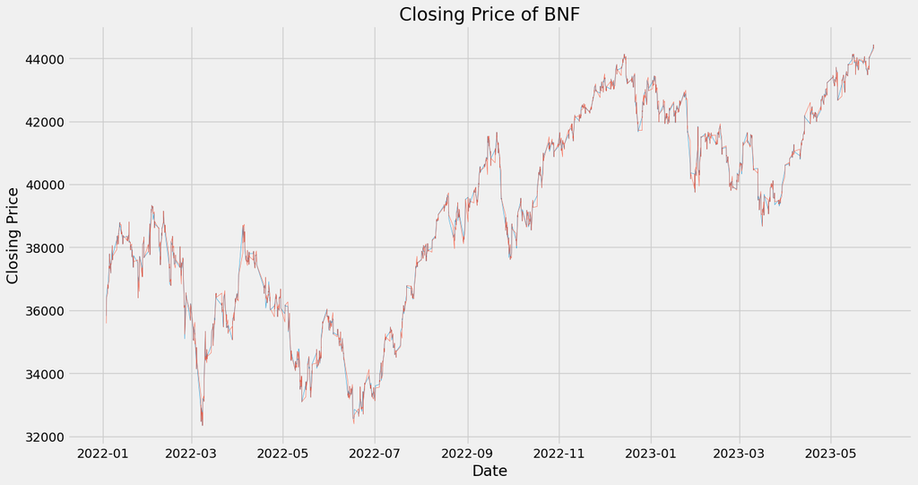

```python
plt.figure(figsize= (15, 8))
plt.title('Closing Price of BNF')
plt.plot(df.Close, linewidth=0.5, alpha=0.8, label='Close')
plt.plot(df.Open, linewidth=0.5, alpha=0.8, label='Open')
plt.xlabel('Date')
plt.ylabel('Closing Price')
plt.show()
```

```python
data = df.filter(['Close'])
# convert data into numpy array
dataset = data.values
# get the number of rows to train data on
training_data_len = math.ceil(len(dataset)*.8)
training_data_len
```

```
1939
```

```python
# scale the data
scaler = MinMaxScaler(feature_range=(0, 1))
scaled_data = scaler.fit_transform(dataset)
scaled_data
```

```
array([[0.28794108],
       [0.29907785],
       [0.30134306],
       ...,
       [0.99918971],
       [0.98981013],
       [0.99065337]])
```

## **LSTM Model**

```python
# create the training dataset
# create the scaled training dataset
train_data = scaled_data[0:training_data_len, :]
# splitting the data into training and test
x_train = []
y_train = []
for i in range(60, len(train_data)):
    x_train.append(train_data[i-60:i, 0])
    y_train.append(train_data[i, 0])
    if i < 61:
        print(x_train)
        print(y_train)
        print()
```

```
[array([0.28794108, 0.29907785, 0.30134306, 0.31605946, 0.32662137,
       0.33678217, 0.34116402, 0.3696751 , 0.36189932, 0.36856317,
       0.35946457, 0.36200687, 0.36985693, 0.37333353, 0.418636  ,
       0.41227832, 0.42627937, 0.45037147, 0.44311662, 0.44479889,
       0.43849481, 0.40447767, 0.40039358, 0.40576335, 0.41600295,
       0.42476665, 0.42250113, 0.42407198, 0.47273124, 0.4625249 ,
       0.44116532, 0.43504307, 0.43491098, 0.44412101, 0.44760601,
       0.48709207, 0.47872108, 0.47474034, 0.47823762, 0.48624463,
       0.49734814, 0.49637249, 0.47640614, 0.49359863, 0.49337547,
       0.50381757, 0.504665  , 0.50476835, 0.50369775, 0.5332339 ,
       0.5312206 , 0.52736387, 0.53307662, 0.52127068, 0.52861629,
       0.52645863, 0.5041276 , 0.51070458, 0.51287063, 0.50610764])]
[0.5029039279203866]
```

```python
#convert into np.array
x_train, y_train = np.array(x_train), np.array(y_train)
```

```python
#reshape the data
x_train = np.reshape(x_train, (x_train.shape[0], x_train.shape[1], 1))
x_train.shape
```

```
(1879, 60, 1)
```

```python
#build the LSTM model
model = Sequential()
model.add(LSTM(5000, return_sequences=True, input_shape=(x_train.shape[1], 1)))
model.add(Dropout(0.2))  # Add dropout layer
model.add(LSTM(5000, return_sequences=False))
model.add(Dropout(0.2))  # Add dropout layer
model.add(Dense(2500))
model.add(Dense(1))
```

```python
# compile the model
from tensorflow.keras.optimizers import SGD
model.compile(optimizer=SGD(learning_rate=0.00001), loss='mean_squared_error')
```

```python
# train the model
# Define early stopping callback
# Experiment with different optimizers, such as Adam, RMSprop, or SGD, and tune their hyperparameters.
early_stopping = EarlyStopping(patience=10, restore_best_weights=True)

# Compile the model with a different optimizer
model.compile(optimizer='SGD', loss='mean_squared_error')

# Train the model with early stopping
model.fit(x_train, y_train, batch_size=1, epochs=1, callbacks=[early_stopping]) # change the epochs to a higher number.
```

```
WARNING:tensorflow:Early stopping conditioned on metric `val_loss` which is not available. Available metrics are: loss
```

```
<keras.callbacks.History at 0x7fd7f069ce50>
```

```python
# create the testing dataset
# create a new dataset containing sclaed values from index
test_data = scaled_data[training_data_len-60: , :]
# create the datasets x_test and y_test
x_test = []
y_test = dataset[training_data_len:, :]
for i in range(60, len(test_data)):
  x_test.append(test_data[i-60:i, 0])
```

```python
# convert the daata to np.array
x_test = np.array(x_test)
```

```python
# reshape the data
x_test = np.reshape(x_test, (x_test.shape[0], x_test.shape[1], 1))
```

## **Model Prediction and Evaluation**

```python
# get the model's predicted price values
predictions = model.predict(x_test)
predictions = scaler.inverse_transform(predictions)
```

```python
# get RMSE
rmse = np.sqrt(np.mean(((predictions - y_test)**2)))
rmse
```

```
361.7366505425037
```

## **Statistical Analysis of Returns**

The script computes daily, weekly, and monthly returns and plots the histogram of these returns. It also calculates certain percentiles (5th, 95th, 15th, and 85th) to visualize the range in which 90% and 70% of the returns lie. This analysis helps in understanding the volatility and risk associated with the Bank Nifty Index.

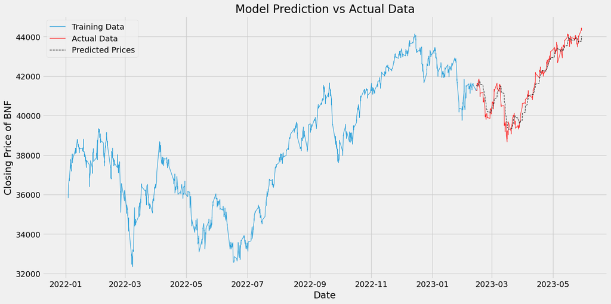

```python
# Plot the data
train = data[:training_data_len]
valid = data[training_data_len:]
valid['Predictions'] = predictions

plt.figure(figsize=(16, 8))
plt.title('Model Prediction vs Actual Data')
plt.xlabel('Date')
plt.ylabel('Closing Price of BNF')

# Plot training data
plt.plot(train['Close'], linewidth=1, alpha=0.8, label='Training Data')

# Plot validation data and predicted prices
plt.plot(valid['Close'], linewidth=1, alpha=0.8, color='red', label='Actual Data')
plt.plot(valid['Predictions'], linewidth=1, linestyle='--', alpha=0.8, color='black', label='Predicted Prices')

plt.legend()
plt.show()
```

## **Trading Strategy Development**

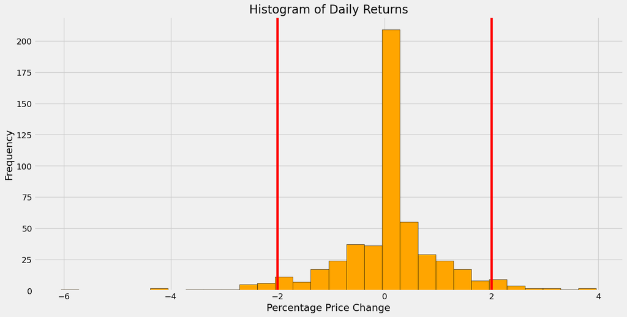

```python
# Resample data to daily frequency and calculate daily returns as percentage price changes
df['Return'] = (df['Close'].resample('D').last().pct_change()*100) # somwhow this is not getting defined

# Plot the histogram of percentage price changes
plt.figure(figsize=(16, 8))
plt.hist((df['Close'].resample('D').last().pct_change()*100).dropna(), bins=30, color='orange', edgecolor='black')
plt.axvline(-2, color= 'red')
plt.axvline(2, color = 'red')
plt.xlabel('Percentage Price Change')
plt.ylabel('Frequency')
plt.title('Histogram of Daily Returns')
plt.show()
```

```python
#Define the ticker symbol for Bank Nifty
ticker = "^NSEBANK"

# Set the start and end dates for the data
start_date = "2017-01-01"
end_date = "2023-05-30"

# Download the daily data for Bank Nifty from Yahoo Finance
df_1 = yf.download(ticker, start=start_date, end=end_date, interval="1d")
```

```
[*********************100%***********************]  1 of 1 completed
```

```python
df_1.head(10)
```

| Date | Open | High | Low | Close | Adj Close | Volume |
| --- | --- | --- | --- | --- | --- | --- |
| 2017-01-03 | 18002.750000 | 18115.050781 | 17830.949219 | 18035.599609 | 18035.390625 | 0 |
| 2017-01-04 | 18037.449219 | 18092.849609 | 17868.900391 | 17891.000000 | 17890.792969 | 0 |
| 2017-01-05 | 18000.750000 | 18164.050781 | 17977.800781 | 18115.949219 | 18115.738281 | 0 |
| 2017-01-06 | 18168.449219 | 18325.500000 | 18157.300781 | 18264.000000 | 18263.787109 | 0 |
| 2017-01-09 | 18314.250000 | 18373.099609 | 18256.150391 | 18286.650391 | 18286.437500 | 0 |
| 2017-01-10 | 18351.449219 | 18441.150391 | 18275.750000 | 18409.599609 | 18409.384766 | 0 |
| 2017-01-11 | 18535.349609 | 18889.449219 | 18515.250000 | 18830.000000 | 18829.781250 | 0 |
| 2017-01-12 | 18885.449219 | 18966.300781 | 18805.849609 | 18873.949219 | 18873.730469 | 0 |
| 2017-01-13 | 18949.699219 | 18952.250000 | 18781.250000 | 18912.099609 | 18911.878906 | 0 |
| 2017-01-16 | 18899.699219 | 19134.500000 | 18865.250000 | 19096.449219 | 19096.226562 | 0 |

```python
# Resample data to weekly frequency from Friday to Thursday
df_weekly = df_1.resample('W-THU').last()

# now we print and check if we have closing price on thursday (indeed we do)
df_weekly.tail(10)
```

| Date | Open | High | Low | Close | Adj Close | Volume |
| --- | --- | --- | --- | --- | --- | --- |
| 2023-03-30 | 39611.550781 | 40055.000000 | 39609.550781 | 39910.148438 | 39910.148438 | 259600 |
| 2023-04-06 | 40940.699219 | 41274.699219 | 40820.550781 | 41041.000000 | 41041.000000 | 196500 |
| 2023-04-13 | 41680.101562 | 42196.199219 | 41502.648438 | 42132.550781 | 42132.550781 | 232600 |
| 2023-04-20 | 42218.500000 | 42378.148438 | 42108.851562 | 42269.500000 | 42269.500000 | 180200 |
| 2023-04-27 | 42753.898438 | 43043.398438 | 42736.601562 | 43000.851562 | 43000.851562 | 181400 |
| 2023-05-04 | 43236.101562 | 43739.800781 | 43213.949219 | 43685.449219 | 43685.449219 | 175400 |
| 2023-05-11 | 43535.101562 | 43774.250000 | 43367.250000 | 43475.300781 | 43475.300781 | 190700 |
| 2023-05-18 | 44006.898438 | 44079.199219 | 43673.699219 | 43752.300781 | 43752.300781 | 226500 |
| 2023-05-25 | 43630.250000 | 43719.851562 | 43390.300781 | 43681.398438 | 43681.398438 | 170200 |
| 2023-06-01 | 44276.800781 | 44483.351562 | 44193.949219 | 44311.898438 | 44311.898438 | 148600 |

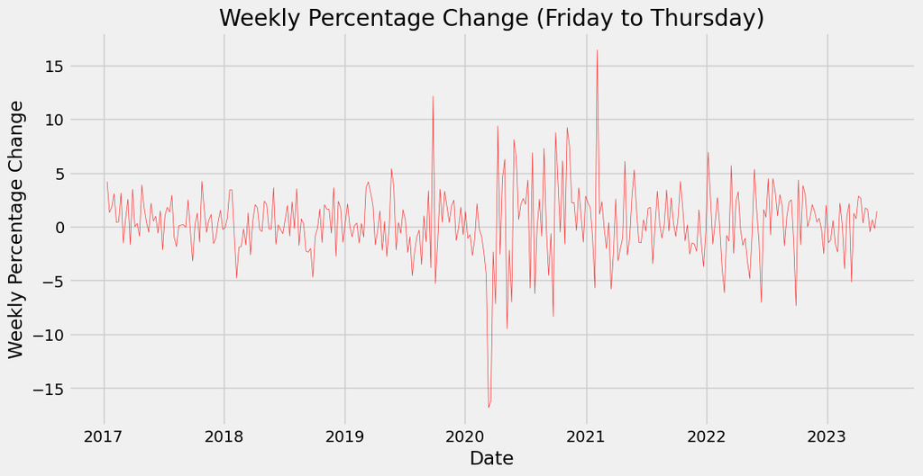

```python
# Calculate weekly percentage change
df_weekly['Weekly_Return'] = df_weekly['Close'].pct_change() * 100

# Plot the weekly percentage change
plt.figure(figsize=(12, 6))
plt.plot(df_weekly['Weekly_Return'], color='red', linewidth=0.5, alpha=0.8)
plt.xlabel('Date')
plt.ylabel('Weekly Percentage Change')
plt.title('Weekly Percentage Change (Friday to Thursday)')
plt.show()
```

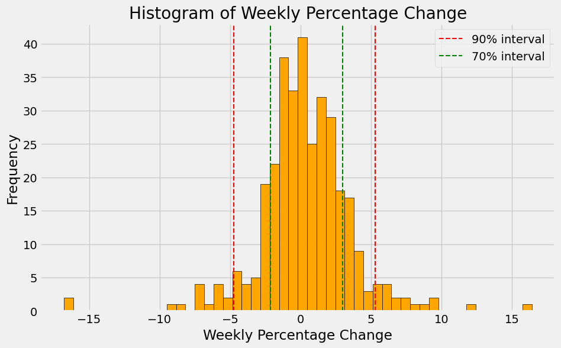

```python
# Plot the histogram of weekly percentage change
plt.figure(figsize=(10, 6))
plt.hist(df_weekly['Weekly_Return'].dropna(), bins=50, color='orange', edgecolor='black')
plt.xlabel('Weekly Percentage Change')
plt.ylabel('Frequency')
plt.title('Histogram of Weekly Percentage Change')

# Calculate the 5th and 95th percentiles
pct_5 = np.percentile(df_weekly['Weekly_Return'].dropna(), 5)
pct_95 = np.percentile(df_weekly['Weekly_Return'].dropna(), 95)
pct_15 = np.percentile(df_weekly['Weekly_Return'].dropna(), 15)
pct_85 = np.percentile(df_weekly['Weekly_Return'].dropna(), 85)

# Draw lines for the 90% and 70% intervals around 0
plt.axvline(pct_5, color='red', linestyle='--', linewidth=1.5, label='90% interval')
plt.axvline(pct_95, color='red', linestyle='--', linewidth=1.5)
plt.axvline(pct_15, color='green', linestyle='--', linewidth=1.5, label='70% interval')
plt.axvline(pct_85, color='green', linestyle='--', linewidth=1.5)

plt.legend()
plt.show()
```

[output not shown]

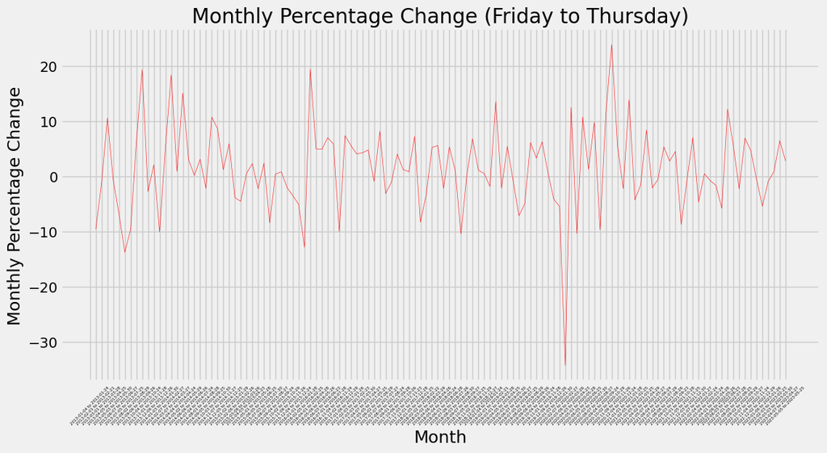

```python
# Define the ticker symbol for Bank Nifty
ticker = "^NSEBANK"

# Set the start and end dates for the data
start_date = "2013-01-01"
end_date = "2023-05-31"

# Download the daily data for Bank Nifty from Yahoo Finance
df_2 = yf.download(ticker, start=start_date, end=end_date)

# Resample data to monthly frequency with custom month definition
def custom_month_labels(date):
    year = date.year
    month = date.month
    first_day = pd.Timestamp(year, month, 1)
    first_friday = first_day + pd.DateOffset(days=(4 - first_day.dayofweek) % 7)
    last_day = pd.Timestamp(year, month, pd.Timestamp(year, month, 1).days_in_month)
    last_thursday = last_day - pd.DateOffset(days=(last_day.dayofweek + 3) % 7)
    if last_thursday >= first_friday:
        last_thursday -= pd.DateOffset(days=1)
    return f"{first_friday.strftime('%Y-%m-%d')} to {last_thursday.strftime('%Y-%m-%d')}"

df_monthly = df_2.groupby(custom_month_labels).last()

# Calculate monthly percentage change
df_monthly['Monthly_Return'] = df_monthly['Close'].pct_change() * 100

# Plot the monthly percentage change as a line plot
plt.figure(figsize=(12, 6))
plt.plot(df_monthly['Monthly_Return'], color='red', linewidth=0.5, alpha=0.8)
plt.xlabel('Month')
plt.ylabel('Monthly Percentage Change')
plt.title('Monthly Percentage Change (Friday to Thursday)')
plt.xticks(rotation=45, size = 4)
plt.show()
```

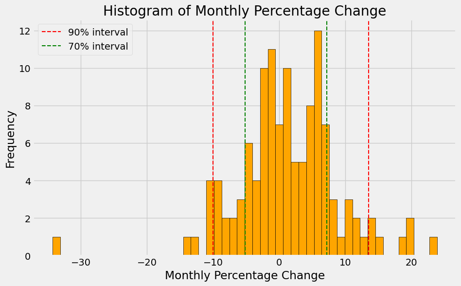

```python
# Plot the histogram of monthly percentage change
plt.figure(figsize=(10, 6))
plt.hist(df_monthly['Monthly_Return'].dropna(), bins=50, color='orange', edgecolor='black')
plt.xlabel('Monthly Percentage Change')
plt.ylabel('Frequency')
plt.title('Histogram of Monthly Percentage Change')

# Calculate the 5th and 95th percentiles
pct_5 = np.percentile(df_monthly['Monthly_Return'].dropna(), 5)
pct_95 = np.percentile(df_monthly['Monthly_Return'].dropna(), 95)
pct_15 = np.percentile(df_monthly['Monthly_Return'].dropna(), 15)
pct_85 = np.percentile(df_monthly['Monthly_Return'].dropna(), 85)

# Draw lines for the 90% and 70% intervals around 0
plt.axvline(pct_5, color='red', linestyle='--', linewidth=1.5, label='90% interval')
plt.axvline(pct_95, color='red', linestyle='--', linewidth=1.5)
plt.axvline(pct_15, color='green', linestyle='--', linewidth=1.5, label='70% interval')
plt.axvline(pct_85, color='green', linestyle='--', linewidth=1.5)

plt.legend()
plt.show()
```

```python
df_monthly.tail(10)
```

| Date | Open | High | Low | Close | Adj Close | Volume | Monthly_Return |
| --- | --- | --- | --- | --- | --- | --- | --- |
| 2022-08-05 to 2022-08-25 | 38516.949219 | 39606.550781 | 38472.699219 | 39536.750000 | 39536.289062 | 176800 | 5.455522 |
| 2022-09-02 to 2022-09-29 | 37660.000000 | 38811.000000 | 37386.351562 | 38631.949219 | 38631.500000 | 246100 | -2.288506 |
| 2022-10-07 to 2022-10-27 | 41265.699219 | 41353.699219 | 41106.101562 | 41307.898438 | 41307.417969 | 237200 | 6.926778 |
| 2022-11-04 to 2022-11-24 | 43122.750000 | 43332.300781 | 42880.050781 | 43231.000000 | 43230.496094 | 202000 | 4.655530 |
| 2022-12-02 to 2022-12-29 | 43401.699219 | 43422.949219 | 42833.101562 | 42986.449219 | 42985.949219 | 258700 | -0.565684 |
| 2023-01-06 to 2023-01-26 | 40563.851562 | 40811.648438 | 40167.699219 | 40655.050781 | 40655.050781 | 289900 | -5.423566 |
| 2023-02-03 to 2023-02-23 | 40302.699219 | 40391.449219 | 40073.000000 | 40269.050781 | 40269.050781 | 327800 | -0.949452 |
| 2023-03-03 to 2023-03-30 | 40231.250000 | 40690.398438 | 40180.199219 | 40608.648438 | 40608.648438 | 188000 | 0.843322 |
| 2023-04-07 to 2023-04-27 | 43045.500000 | 43302.050781 | 42810.351562 | 43233.898438 | 43233.898438 | 238700 | 6.464756 |
| 2023-05-05 to 2023-05-25 | 44277.351562 | 44498.601562 | 44207.500000 | 44436.351562 | 44436.351562 | 157600 | 2.781274 |

**Now we will try to develop a good trading strategy for BNF using chandilier exit and contraction zones.**

## **Backtesting**

Finally, the script performs a backtest of the trading strategy, which involves simulating what the returns would have been if the strategy had been followed with an initial capital of 100,000 units. The script assumes that we can take a long position (buy) when the buy signal is triggered and that we should exit the position (sell) when the sell signal is triggered.

```python
!pip install ta
import ta
import yfinance as yf
from itertools import product

# Define parameter ranges
atr_periods = range(1, 21)  # ATR periods to test
atr_multipliers = [i / 2.0 for i in range(21)]  # ATR multipliers to test

# Define performance metrics
metrics = ['metric1', 'metric2', 'metric3']  # Add your desired performance metrics here

# Initialize results dictionary
results = {metric: [] for metric in metrics}

# Iterate over parameter combinations
for period, multiplier in product(atr_periods, atr_multipliers):
    # Calculate ATR
    df_2['atr'] = ta.volatility.average_true_range(df_2['High'], df_2['Low'], df_2['Close'], window=period)

    # Calculate Chandelier Exit
    df_2['long_stop'] = df_2['High'].rolling(period).max() - (multiplier * df_2['atr'])
    df_2['short_stop'] = df_2['Low'].rolling(period).min() + (multiplier * df_2['atr'])

    # Generate buy/sell signals
    df_2['buy_signal'] = (df_2['Close'] > df_2['short_stop'].shift()) & (df_2['Close'].shift() < df_2['long_stop'])
    df_2['sell_signal'] = (df_2['Close'] < df_2['long_stop'].shift()) & (df_2['Close'].shift() > df_2['short_stop'])

    # Calculate performance metrics
    # Replace the code below with your own calculations for the desired performance metrics
    metric1 = df_2['buy_signal'].sum()
    metric2 = df_2['sell_signal'].sum()
    metric3 = metric1 / metric2  # Example calculation

    # Append results to the respective metric lists
    results['metric1'].append(metric1)
    results['metric2'].append(metric2)
    results['metric3'].append(metric3)

# Convert results to a DataFrame for analysis
results_df = pd.DataFrame(results)

# Find the parameter combination with the best performance for each metric
best_params = {metric: results_df[metric].idxmax() for metric in metrics}

# Print the optimal parameters for each metric
for metric, best_param in best_params.items():
    print(f"Optimal {metric}: ATR Period={atr_periods[best_param // len(atr_multipliers)]}, "
          f"ATR Multiplier={atr_multipliers[best_param % len(atr_multipliers)]}")
```

```
  Preparing metadata (setup.py) ... done
```

[output not shown]

[output cut: 485 more lines]

[output not shown]

```
Optimal metric1: ATR Period=20, ATR Multiplier=0.0
Optimal metric2: ATR Period=20, ATR Multiplier=0.0
Optimal metric3: ATR Period=3, ATR Multiplier=2.0
```

```python
# Define the ticker symbol for Bank Nifty
ticker = "^NSEBANK"

# Set the start and end dates for the data
start_date = "2013-01-01"
end_date = "2023-05-31"

# Download the daily data for Bank Nifty from Yahoo Finance
df_2 = yf.download(ticker, start=start_date, end=end_date)
# Set the optimal parameters obtained from parameter optimization
optimal_period = 7
optimal_multiplier = 2.5

# Calculate ATR
df_2['atr'] = ta.volatility.average_true_range(df_2['High'], df_2['Low'], df_2['Close'], window=optimal_period)

# Calculate Chandelier Exit
df_2['long_stop'] = df_2['High'].rolling(optimal_period).max() - (optimal_multiplier * df_2['atr'])
df_2['short_stop'] = df_2['Low'].rolling(optimal_period).min() + (optimal_multiplier * df_2['atr'])

# Generate buy/sell signals
df_2['buy_signal'] = (df_2['Close'] > df_2['short_stop'].shift()) & (df_2['Close'].shift() < df_2['long_stop'])
df_2['sell_signal'] = (df_2['Close'] < df_2['long_stop'].shift()) & (df_2['Close'].shift() > df_2['short_stop'])

# Backtest simulation
capital = 100000  # Initial capital
position = 0  # Position in the market (0 for no position, 1 for long, -1 for short)
shares = 0  # Number of shares held
portfolio = []  # Portfolio value over time

for i in range(len(df_2)):
    if df_2['buy_signal'].iloc[i]:
        if position == 0:  # Enter long position
            shares = capital / df_2['Close'].iloc[i]
            capital = 0
            position = 1
    elif df_2['sell_signal'].iloc[i]:
        if position == 1:  # Exit long position
            capital = shares * df_2['Close'].iloc[i]
            shares = 0
            position = 0
    portfolio.append(capital + shares * df_2['Close'].iloc[i])

# Calculate portfolio returns
returns = (portfolio[-1] - portfolio[0]) / portfolio[0] * 100

print(f"Backtest Returns: {returns:.2f}%")
```

```
[*********************100%***********************]  1 of 1 completed
Backtest Returns: 288.24%
```

## **Conclusion**

This script provides a comprehensive workflow for analyzing stock market data, developing trading strategies based on technical indicators, and backtesting those strategies to assess their potential profitability. It is a useful tool for anyone interested in quantitative finance, algorithmic trading, or stock market analysis.